# BMIN503/EPID600 Final Project

Emily Johnson

### Overview

> Neonatal abstinence syndrome (NAS) is is a postnatal opioid withdrawal syndrome, characterized by impaired respiration, feeding, and weight gain, which affects a newborn every 25 minutes in the United States (Patrick et al, 2015). I will performing both an epidemiological analysis of NAS and a single cell RNA sequencing analysis for midbrain development, as NAS is controlled by the midbrain dopaminergic pathway, and this healthy development analysis will be used to compare NAS single cell RNA sequencing data at a later date. This work is supported by Dr. Kam Leong and Dr. Hyesung Kim in Columbia BME.

# Introduction

> The human brain and its development are immensely complex, and during development the brain is especially vulnerable to external toxicity and injury. Opioid use is on the rise in the United States, with 11.3% of Americans abusing non-prescription opioids in their lifetime, in what has been described as an epidemic (Saha et al, 2016). This increase in opioid use disorder (OUD) extends to mothers, and as maternal OUD increases, so does neonatal abstinence syndrome (NAS). Neonatal abstinence syndrome is a postnatal opioid withdrawal syndrome, characterized by impaired respiration, feeding, and weight gain (McQueen et al, 2016). There is also evidence that opioid exposure during pregnancy and infanthood results in epigenetic changes in future generations (Maguire et al, 2016). Incidence of NAS increased nearly fivefold between 2000 and 2012, and by 2012 an infant was born with the syndrome every 25 minutes in the US (Patrick et al, 2015). In addition to the negative effects of the syndrome on infants, the uptick in NAS has significant economic consequences—the syndrome accounts for a total of $1.5 billion in hospital charges, and approximately 80% of infants born with NAS in the US are enrolled in Medicaid (Patrick et al, 2015). Thus, opioid exposure in utero gives rise to numerous detrimental short-term and long-term effects at an individual and societal level.

> Despite the wide impact of NAS, there is little research on it’s effects, especially on the molecular and cellular level. For my project I plan to dually take an epidemiological and molecular approach to reviewing NAS, and this interdiscioplinary approach can hopefully help develop a fuller picture of NAS. From my work with Dr. Kim we established that scRNA analysis is the best way to study NAS on a molecular level, as the initial methods employed for expression analysis, such as qPCR, are thrown off by drug doses given to the organoids and don’t yield consistent results.

## Methods

### Libraries

First I will read in the libraries

```r
#epi
library(ggplot2)
library(RColorBrewer)
library(viridis)
library(car)
library(dplyr)
library(sf)
#scRNA
library(GEOquery)
library(Seurat)
library(edgeR)
library(limma)
library(gplots)
library(RColorBrewer)
library(Matrix)
library(gdata)
```

## Epidemiology of NAS

### Loading and cleaning data

All data from PHC4 via opendataPA

#### Overall overdose in PA

Reading in the dataset then removing all variables that are not needed

```r
overdose <- read.csv("Overdose_Information_Network_Data_CY_January_2018_-_Current_Monthly_County_State_Police.csv")

overdose <- overdose %>%
  select(-c("Incident.ID", "Incident.Time", "Victim.ID", "Victim.State", "Victim.County", "Accidental.Exposure", "Administration.ID", "Dose.Count", "Dose.Unit", "Dose.Desc", "Response.Time.Desc", "Response.Desc", "Revive.Action.Desc", "Third.Party.Admin.Desc", "Victim.County.FIPS.Code", "Victim.County.Latitude", "Victim.County.Longitude", "Victim.County.Latitude.and.Longitude")) %>%
 group_by(Incident.County.Name) %>% mutate(count = n())
```

#### NAS data by county

Reading in the datasets, removing unneeded variables, combining into one frame, and filtering for consistent time periods

```r
#Rate of neonatal hospital stays with withdrawal symptoms during birth hospitalization (first 28 days of life) per 1,000 livebirths
county.withdrawal.stays <- read.csv("Rate_of_Neonatal_Hospital_Stays_with_Withdrawal_Symptoms_from_Maternal_Use_of_Drugs_of_Addiction_CY_2016-Current_County_Health_Care_Cost_Containment_Council__PHC4_.csv")

county.OUD.diagnosis <- read.csv("Rate_of_Women_Diagnosed_with_Opioid_Use_Disorder__OUD__during_Pregnancy_CY_2016_-_Current_Statewide_Health_Care_Cost_Containment_Council__PHC4_.csv")

county.MA <- read.csv("Rate_of_Women_on_Medical_Assistance__MA__Diagnosed_with_Opioid_Use_Disorder__OUD__during_Pregnancy_CY_2016-Current_Statewide_Department_of_Human_Services__DHS_.csv")

#cleaning---------------------
county.MA <- county.MA %>%
  select(-c("Time.Period.Dates", "Type.of.Rate", "Number.of.Women.with.a.Delivery.and.OUD.Diagnosis.notes", "Number.of.Women.with.a.Delivery.and.OUD.Description", "Total.Number.of.Deliveries.Description", "Total.Number.of.Deliveries.Notes", "County.Code.Text", "County.Code.Number")) %>%
  filter(Geographic.Area == "County")

county.OUD.diagnosis <- county.OUD.diagnosis %>%
    filter(Geographic.Area == "County") %>%
  select(c("Rate.of.Pregnant.Women.with.OUD.Diagnosis.at.Delivery", "County.FIPS.Code", "Time.Period", "Geographic.Name"))
county.withdrawal.stays <- county.withdrawal.stays %>%
  filter(Geographic.Area == "County") %>%
  select(c("Rate.of.Neonatal.Hospital.Stays.with.Withdrawal.Symptoms", "County.FIPS.Code", "Time.Period", "Geographic.Name"))

county.withdrawal.stays$Geographic.Name <- paste(county.withdrawal.stays$Geographic.Name, "County", sep=" ")

county <- full_join(county.MA, county.OUD.diagnosis, by = c("Geographic.Name", "Time.Period"))
county <- full_join(county, county.withdrawal.stays, by = c("Geographic.Name", "Time.Period"))
county <- full_join(county.MA, county.OUD.diagnosis, by = c("County.FIPS.Code", "Time.Period"))
county <- full_join(county.withdrawal.stays, county, by = c("County.FIPS.Code", "Time.Period"))


county <- county %>%
  filter(Time.Period == c("2016 Annual", "2017 Annual"))

philadelphia <- county %>%
  filter(Geographic.Name == "Philadelphia County")
```

#### NAS data for PA over time

Reading in the datasets and removing unneeded variables

```r
rate.of.NAS <- read.csv("Rate_of_Neonatal_Abstinence_Syndrome_per_1_000_Newborn_Stays_FYs_2000-2001_to_FYs_2016-2017_Statewide_Health_Care_Cost_Containment_Council__PHC4_.csv")

rate.of.OUD <- read.csv("Statewide_Maternal_Hospital_Stays_Opioid_Use_Rates_2000_to_present__PA_Health_Care_Cost_Containment_Council__PHC4_.csv")

rate.of.NAS <- rate.of.NAS %>%
    select(-c("State.Name", "Time.Period.Date.Start", "Time.Period.Date.End", "Type.of.Rate", "Time.Period", "State.FIPS.Code"))

rate.of.OUD <- rate.of.OUD %>%
     select(-c("State", "Time.Period.Date.Start", "Time.Period.Date.End", "Type.of.Rate"))

rate.of.OUD.NAS <- cbind(rate.of.OUD, rate.of.NAS)
```

#### NAS data for PA in 2016/17

Reading in the datasets, removing unneeded variables, joining frames using the same time periods

```r
PA.gestation.stage <- read.csv("Statewide_Delivery_Stays_Percent_of_Gestation_Stages_with_or_without_Opioid_Use_2016-2017_PA_Health_Care_Cost_Containment_Council__PHC4_.csv")

PA.readmission <- read.csv("Statewide_Delivery_Stays_Percent_Readmitted_with_or_without_Opioid_Use_2016-2017_PA_Health_Care_Cost_Containment_Council__PHC4_.csv")

PA.medicaid.OUD <- read.csv("Statewide_Maternal_Stays_percent_Medicaid_with_or_without_Opioid_Use_2016-2017_PA_Health_Care_Cost_Containment_Council__PHC4_.csv")

PA.medicaid.NAS<- read.csv("Newborn_Hospital_Stays_with_Neonatal_Abstinence_Syndrome_Percent_Paid_by_Medicaid_Statewide_Health_Care_Cost_Containment_Council__PHC4_.csv")

PA.gestation.stage <- PA.gestation.stage %>%
     select(-c("State", "State.FIPS.Code", "Time.Period", "Time.Period.Date.Start", "Time.Period.Date.End"))

PA.readmission <- PA.readmission %>%
  select(-c("State", "State.FIPS.Code", "Time.Period", "Time.Period.Date.Start", "Time.Period.Date.End"))

PA.medicaid.NAS <- PA.medicaid.NAS %>%
  select(-c("State.Name", "State.FIPS.Code", "Time.Period", "Time.Period.Date.Start", "Time.Period.Date.End"))

PA.medicaid.OUD <- PA.medicaid.OUD %>%
  select(-c("State", "State.FIPS.Code", "Time.Period", "Time.Period.Date.Start", "Time.Period.Date.End"))

PA.readmission.medicaid <- inner_join(PA.readmission, PA.medicaid.OUD)
```

## Molecular Analysis of Midbrain Development

Read in GSEmatrix

```r
gse <- getGEO("GSE127967", GSEMatrix = TRUE)
```

```
## Found 1 file(s)
```

```
## GSE127967_series_matrix.txt.gz
```

```
## File stored at:
```

```
## /var/folders/cw/whkpmwc17dd00g8c____gvdc0000gn/T//RtmpQkY12t/GPL10558.soft
```

```r
expr.set <- as.data.frame(exprs(gse[[1]]))

expr <- gse[[1]]
colnames(pData(expr))
```

```
##  [1] "title"                   "geo_accession"           "status"                  "submission_date"         "last_update_date"        "type"                    "channel_count"           "source_name_ch1"         "organism_ch1"            "characteristics_ch1"     "characteristics_ch1.1"   "growt…
## [16] "label_protocol_ch1"      "taxid_ch1"               "hyb_protocol"            "scan_protocol"           "data_processing"         "platform_id"             "contact_name"            "contact_institute"       "contact_address"         "contact_city"            "contact_zip/postal_code" "conta…
## [31] "passage:ch1"
```

```r
pData(expr)$data_processing[1]
```

```
## [1] Cubic Spline normalization with background subtraction in Illumina GenomeStudio
## Levels: Cubic Spline normalization with background subtraction in Illumina GenomeStudio
```

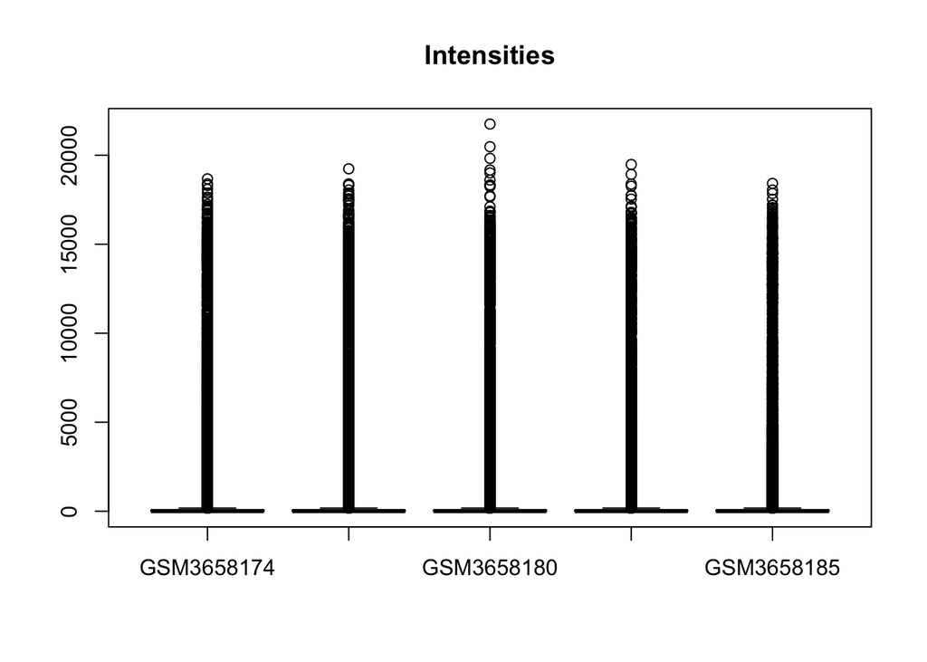

```r
boxplot(expr.set, col = "red", main = "Intensities")
```

```r
#explore expression set
head(exprs(expr))
```

```
##                GSM3658174   GSM3658177    GSM3658180   GSM3658183    GSM3658185
## ILMN_1343291 18673.840000 19239.350000 19169.0900000 17068.570000 16291.9900000
## ILMN_1343295  7331.348000  7973.783000  5854.6560000  8719.269000  8193.4190000
## ILMN_1651199    -3.420142    -7.237599    -1.6069790     1.433674    -1.0290920
## ILMN_1651209    16.876720     7.078369    12.6789600    17.226910    23.9212900
## ILMN_1651210    -4.070359     3.373008     2.8547850    -2.835819    -0.6723484
## ILMN_1651221     1.707713     1.621571    -0.2872103     3.457790     1.2555190
```

```r
summary(exprs(expr))
```

```
##    GSM3658174          GSM3658177          GSM3658180          GSM3658183          GSM3658185
##  Min.   :  -12.002   Min.   :  -11.849   Min.   :  -10.826   Min.   :  -12.361   Min.   :  -10.303
##  1st Qu.:   -0.082   1st Qu.:   -0.082   1st Qu.:   -0.084   1st Qu.:   -0.080   1st Qu.:   -0.080
##  Median :    6.476   Median :    6.476   Median :    6.476   Median :    6.476   Median :    6.476
##  Mean   :  289.189   Mean   :  289.246   Mean   :  289.231   Mean   :  288.980   Mean   :  288.628
##  3rd Qu.:   71.637   3rd Qu.:   71.859   3rd Qu.:   71.719   3rd Qu.:   71.809   3rd Qu.:   71.658
##  Max.   :18673.840   Max.   :19239.350   Max.   :21752.620   Max.   :19481.610   Max.   :18417.040
```

```r
#dataframe of pheno data
my.pdata <- as.data.frame(pData(expr), stringsAsFactors=F)
head(my.pdata)
```

```
##                  title geo_accession                status submission_date last_update_date type channel_count source_name_ch1 organism_ch1                                            characteristics_ch1 characteristics_ch1.1
## GSM3658174  mfNPC-1_P2    GSM3658174 Public on Mar 07 2019     Mar 06 2019      Mar 07 2019  RNA             1    Cell culture Homo sapiens cell type: midbrain floorplate neural progenitor cells (mfNPC)            passage: 2
## GSM3658177  mfNPC-2_P2    GSM3658177 Public on Mar 07 2019     Mar 06 2019      Mar 07 2019  RNA             1    Cell culture Homo sapiens cell type: midbrain floorplate neural progenitor cells (mfNPC)            passage: 2
## GSM3658180 mfNPC-1_P12    GSM3658180 Public on Mar 07 2019     Mar 06 2019      Mar 07 2019  RNA             1    Cell culture Homo sapiens cell type: midbrain floorplate neural progenitor cells (mfNPC)           passage: 12
## GSM3658183 mfNPC-2_P12    GSM3658183 Public on Mar 07 2019     Mar 06 2019      Mar 07 2019  RNA             1    Cell culture Homo sapiens cell type: midbrain floorplate neural progenitor cells (mfNPC)           passage: 12
## GSM3658185   smNPC_P10    GSM3658185 Public on Mar 07 2019     Mar 06 2019      Mar 07 2019  RNA             1    Cell culture Homo sapiens       cell type: small molecule neural precursor cells (smNPC)           passage: 10
##                                                                                                                                                                                                                             growth_protocol_ch1 molecule_ch1                           extract_protocol_c…
## GSM3658174 completely confluent human pluripotent stem cells were differentiated as a monolayer on matrigel using double-SMAD inhibition by SB-431542, Dorsomorphin and Purmorphamine and matured for 30 days with spliting when too confluent.    total RNA Qiagen RNeasy kit with on-column DNA digesti…
## GSM3658177 completely confluent human pluripotent stem cells were differentiated as a monolayer on matrigel using double-SMAD inhibition by SB-431542, Dorsomorphin and Purmorphamine and matured for 30 days with spliting when too confluent.    total RNA Qiagen RNeasy kit with on-column DNA digesti…
## GSM3658180 completely confluent human pluripotent stem cells were differentiated as a monolayer on matrigel using double-SMAD inhibition by SB-431542, Dorsomorphin and Purmorphamine and matured for 30 days with spliting when too confluent.    total RNA Qiagen RNeasy kit with on-column DNA digesti…
## GSM3658183 completely confluent human pluripotent stem cells were differentiated as a monolayer on matrigel using double-SMAD inhibition by SB-431542, Dorsomorphin and Purmorphamine and matured for 30 days with spliting when too confluent.    total RNA Qiagen RNeasy kit with on-column DNA digesti…
## GSM3658185 completely confluent human pluripotent stem cells were differentiated as a monolayer on matrigel using double-SMAD inhibition by SB-431542, Dorsomorphin and Purmorphamine and matured for 30 days with spliting when too confluent.    total RNA Qiagen RNeasy kit with on-column DNA digesti…
##                                                                 hyb_protocol                                scan_protocol                                                                 data_processing platform_id     contact_name contact_institute    contact_address contact_city contact_zip/post…
## GSM3658174 According to manufacturer's instructions. Hybridization time: 18h Illumina iScan system using default settings Cubic Spline normalization with background subtraction in Illumina GenomeStudio    GPL10558 Lydia,,Reinhardt              CRTD Fetscherstraße 105      Dresden                 …
## GSM3658177 According to manufacturer's instructions. Hybridization time: 18h Illumina iScan system using default settings Cubic Spline normalization with background subtraction in Illumina GenomeStudio    GPL10558 Lydia,,Reinhardt              CRTD Fetscherstraße 105      Dresden                 …
## GSM3658180 According to manufacturer's instructions. Hybridization time: 18h Illumina iScan system using default settings Cubic Spline normalization with background subtraction in Illumina GenomeStudio    GPL10558 Lydia,,Reinhardt              CRTD Fetscherstraße 105      Dresden                 …
## GSM3658183 According to manufacturer's instructions. Hybridization time: 18h Illumina iScan system using default settings Cubic Spline normalization with background subtraction in Illumina GenomeStudio    GPL10558 Lydia,,Reinhardt              CRTD Fetscherstraße 105      Dresden                 …
## GSM3658185 According to manufacturer's instructions. Hybridization time: 18h Illumina iScan system using default settings Cubic Spline normalization with background subtraction in Illumina GenomeStudio    GPL10558 Lydia,,Reinhardt              CRTD Fetscherstraße 105      Dresden                 …
##                                                  cell type:ch1 passage:ch1
## GSM3658174 midbrain floorplate neural progenitor cells (mfNPC)           2
## GSM3658177 midbrain floorplate neural progenitor cells (mfNPC)           2
## GSM3658180 midbrain floorplate neural progenitor cells (mfNPC)          12
## GSM3658183 midbrain floorplate neural progenitor cells (mfNPC)          12
## GSM3658185       small molecule neural precursor cells (smNPC)          10
```

```r
dim(my.pdata)
```

```
## [1]  5 31
```

```r
colnames(my.pdata)
```

```
##  [1] "title"                   "geo_accession"           "status"                  "submission_date"         "last_update_date"        "type"                    "channel_count"           "source_name_ch1"         "organism_ch1"            "characteristics_ch1"     "characteristics_ch1.1"   "growt…
## [16] "label_protocol_ch1"      "taxid_ch1"               "hyb_protocol"            "scan_protocol"           "data_processing"         "platform_id"             "contact_name"            "contact_institute"       "contact_address"         "contact_city"            "contact_zip/postal_code" "conta…
## [31] "passage:ch1"
```

```r
head(my.pdata[, c("title", "geo_accession")], 5)
```

```
##                  title geo_accession
## GSM3658174  mfNPC-1_P2    GSM3658174
## GSM3658177  mfNPC-2_P2    GSM3658177
## GSM3658180 mfNPC-1_P12    GSM3658180
## GSM3658183 mfNPC-2_P12    GSM3658183
## GSM3658185   smNPC_P10    GSM3658185
```

```r
my.pdata <- my.pdata[, c("title", "geo_accession")]
my.pdata <- my.pdata[order(rownames(my.pdata)), ]
head(my.pdata, 5)
```

```
##                  title geo_accession
## GSM3658174  mfNPC-1_P2    GSM3658174
## GSM3658177  mfNPC-2_P2    GSM3658177
## GSM3658180 mfNPC-1_P12    GSM3658180
## GSM3658183 mfNPC-2_P12    GSM3658183
## GSM3658185   smNPC_P10    GSM3658185
```

```r
head(rownames(my.pdata))
```

```
## [1] "GSM3658174" "GSM3658177" "GSM3658180" "GSM3658183" "GSM3658185"
```

```r
# gse <- getGEO("GSE127967", GSEMatrix = FALSE)
#
# gsmplatforms <- lapply(GSMList(gse),function(x) {Meta(x)$platform})
# Table(GSMList(gse)[[1]])
# Columns(GSMList(gse)[[1]])
# probesets <- Table(GPLList(gse)[[1]])$ID
#
# data.matrix <- do.call('cbind',lapply(GSMList(gse),function(x)
#   {tab <- Table(x)
#   mymatch <- match(probesets,tab$ID_REF)
#  return(tab$VALUE[mymatch])
#  }))
# data.matrix <- apply(data.matrix,2,function(x) {as.numeric(as.character(x))})
# data.matrix <- log2(data.matrix)
# data.matrix[1:5,]
#
# rownames(data.matrix) <- probesets
# colnames(data.matrix) <- names(GSMList(gse))
# pdata <- data.frame(samples=names(GSMList(gse)))
# rownames(pdata) <- names(GSMList(gse))
# pheno <- as(pdata,"AnnotatedDataFrame")
# eset2 <- new('ExpressionSet',exprs=data.matrix,phenoData=pheno)
# eset2
```

# Results

## Epidemiology of NAS

### Overdoses – Introducing the Epidemic

Map of overdose rate by county in PA

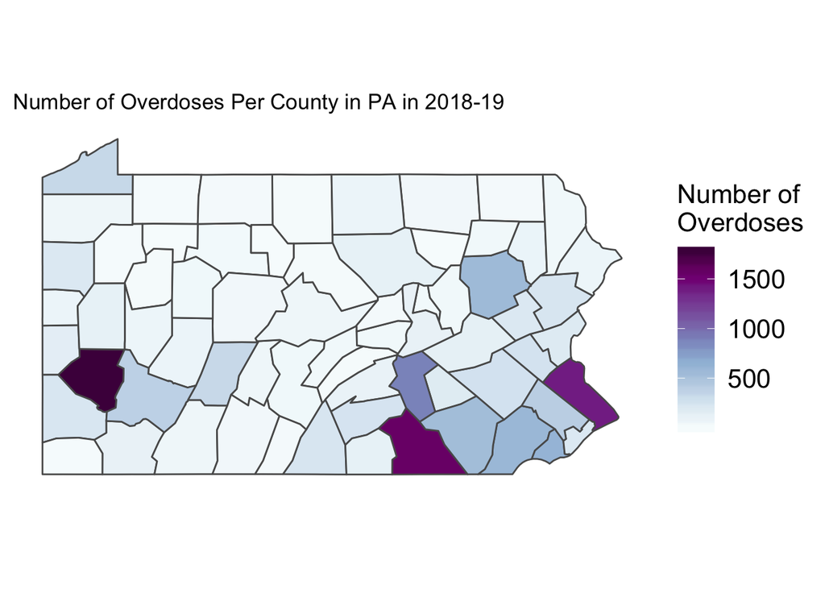

```r
#read in US map
counties <- readRDS(gzcon(url("https://raw.githubusercontent.com/HimesGroup/BMIN503/master/DataFiles/uscounties_2010.rds")))

#filter to just PA
counties <- counties %>%
  filter(STATE == 42) %>%
  rename(County.FIPS.Code = COUNTY)

#clean overdose data for mapping
overdose.counts <- overdose %>%
  group_by(Incident.County.Name, Incident.County.Latitude.and.Longitude, Incident.County.FIPS.Code) %>%
  summarise(count = mean(count)) %>%
  rename(County.FIPS.Code = Incident.County.FIPS.Code) %>%
  mutate(County.FIPS.Code = sprintf("%03d", County.FIPS.Code))

overdose.map <- inner_join(counties, overdose.counts, by = "County.FIPS.Code")
myPalette <- colorRampPalette(brewer.pal(9, "BuPu"))  # RColorBrewer palette

# To save space, we can save theme commands as a function that we can "add" to calls to ggplot
my_theme <- function() {
  theme_minimal() +                                  # shorthand for white background color
  theme(axis.line = element_blank(),                 # further customization of theme components
        axis.text = element_blank(),                 # remove x and y axis text and labels
        axis.title = element_blank(),
        panel.grid = element_line(color = "white"),  # make grid lines invisible
        legend.key.size = unit(0.8, "cm"),           # increase size of legend
        legend.text = element_text(size = 16),       # increase legend text size
        legend.title = element_text(size = 16))      # increase legend title size
}

ggplot() +
  geom_sf(data = overdose.map, aes(fill = count, geometry = geometry)) +
  my_theme() +                                           # add our custom theme
  ggtitle("Number of Overdoses Per County in PA in 2018-19") + # add plot title
  scale_fill_gradientn(name = "Number of \nOverdoses",      # change legend title
                    colours = myPalette(100))            # RColorBrewer palette OR
```

```r
                    #colours = viridis(100))             # viridis palette
```

Overdose rates are highest in Dauphin, York, Bucks, and Allegheny Counties. These are the 14th, 8th, 4th, and 2nd most populous counties in PA respectively, indicating that overdose rates are not completely in line with population. Increasingly opioid addiction has become a problem in rural areas, so increasing overdoses in less populous areas is to be expected.

Graph of overdose broken by drug type, to see trends in overdose cause

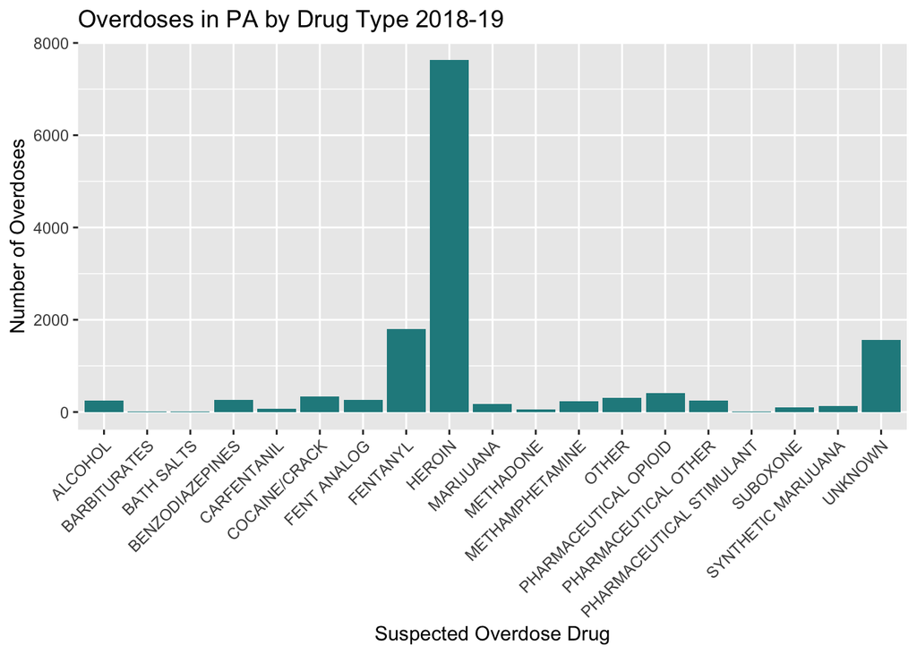

```r
#shorten drug type names for ease
overdose$Susp.OD.Drug.Desc <- gsub("FENTANYL ANALOG/OTHER SYNTHETIC OPIOID", "FENT ANALOG", overdose$Susp.OD.Drug.Desc)
overdose$Susp.OD.Drug.Desc <- gsub("BENZODIAZEPINES (I.E.VALIUM, XANAX, ATIVAN, ETC)", "BENZODIAZEPINES", overdose$Susp.OD.Drug.Desc, fixed=TRUE)
overdose$Susp.OD.Drug.Desc <- gsub("BARBITURATES (I.E. AMYTAL, NEMBUTAL, ETC)", "BARBITURATES", overdose$Susp.OD.Drug.Desc, fixed=TRUE)


ggplot(data = overdose, aes(x = Susp.OD.Drug.Desc)) + geom_bar(fill = "#238A8DFF") +
  theme(axis.text.x = element_text(angle = 45, hjust = 1)) +
  ggtitle("Overdoses in PA by Drug Type 2018-19") +
  xlab("Suspected Overdose Drug") + ylab("Number of Overdoses")
```

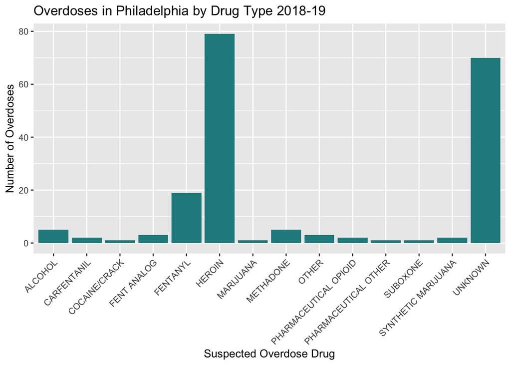

```r
ggplot(data = overdose %>% filter(Incident.County.Name == "Philadelphia"), aes(x = Susp.OD.Drug.Desc)) + geom_bar(fill = "#238A8DFF") +
  theme(axis.text.x = element_text(angle = 45, hjust = 1)) +
  ggtitle("Overdoses in Philadelphia by Drug Type 2018-19") +
  xlab("Suspected Overdose Drug") + ylab("Number of Overdoses")
```

The highest drug overdose types across the state and in Philadelphia are fentanyl and heroin (discounting unknown types). Fentanyl is incredibly potent, leading to overdose. It’s rise is therefore deeply concerning, which is why my lab and I have performed our experiments on OUD and NAS using a fentanyl model.

Graph of overdoses over the past year in Philadelphia and PA by demographics

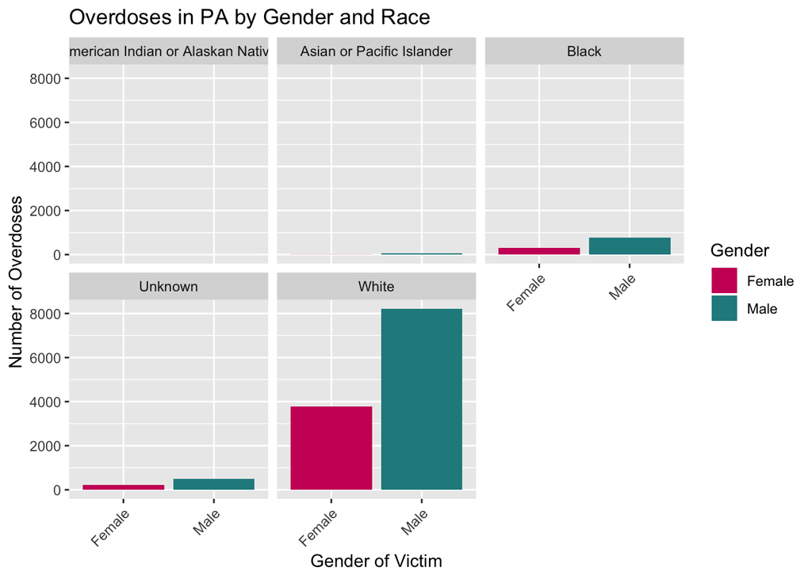

```r
#group by gender and race. stack male and female and plot diff ethnicities
ggplot(data = overdose  %>% filter(Gender.Desc != "Unknown"), aes(x = Gender.Desc, fill = Gender.Desc)) + geom_bar() +
  facet_wrap(~Race) +
  theme(axis.text.x = element_text(angle = 45, hjust = 1)) +
  ggtitle("Overdoses in PA by Gender and Race") +
  xlab("Gender of Victim") + ylab("Number of Overdoses") +
  labs(fill = "Gender") +
  scale_fill_manual(values=c("#CC0066", "#238A8DFF"))
```

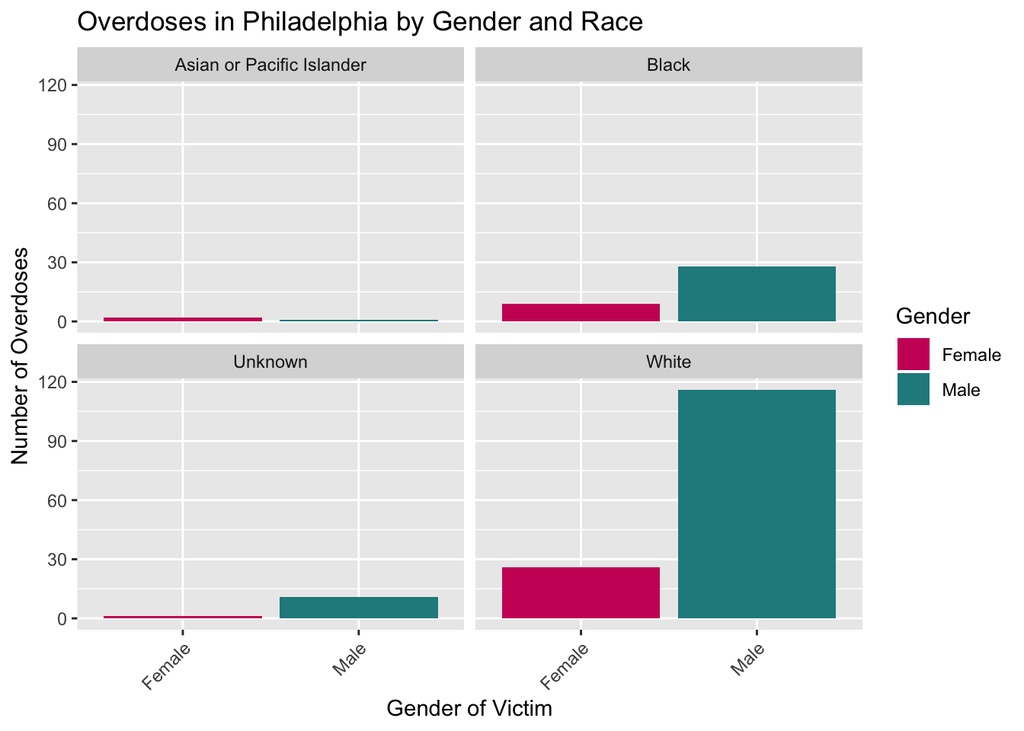

```r
ggplot(data = overdose %>% filter(Incident.County.Name == "Philadelphia"), aes(x = Gender.Desc, fill = Gender.Desc)) + geom_bar() +
  facet_wrap(~Race) +
  theme(axis.text.x = element_text(angle = 45, hjust = 1)) +
  ggtitle("Overdoses in Philadelphia by Gender and Race") +
  xlab("Gender of Victim") + ylab("Number of Overdoses") +
  labs(fill = "Gender") +
  scale_fill_manual(values=c("#CC0066", "#238A8DFF"))
```

Drug overdoses are higher in males, and overdose rates are highest in white Pennsylvanians and Philadelphians.

### NAS PA data – how NAS affects individuals and society

Graph of rate of NAS over time increase

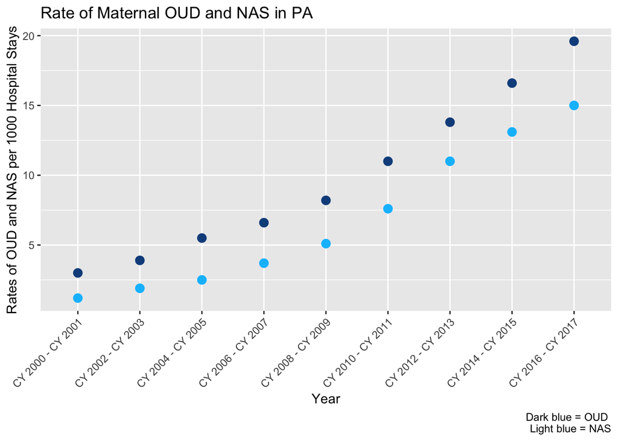

```r
ggplot(data = rate.of.OUD.NAS) + geom_point(aes(x = Time.Period, y = Rate.of.Newborn.NAS.Stays), color = "deepskyblue1", size = 3) + geom_point(aes(x = Time.Period, y = Rate.of.Maternal.Stays.with.Opioid.Use), color = "dodgerblue4", size = 3) +
  theme(axis.text.x = element_text(angle = 45, hjust = 1)) +
  ggtitle("Rate of Maternal OUD and NAS in PA") +
  xlab("Year") + ylab("Rates of OUD and NAS per 1000 Hospital Stays") +
  labs(caption = "Dark blue = OUD \nLight blue = NAS")
```

Maternal opioid use and NAS have been increasing steadily each year.

Graph of gestational state

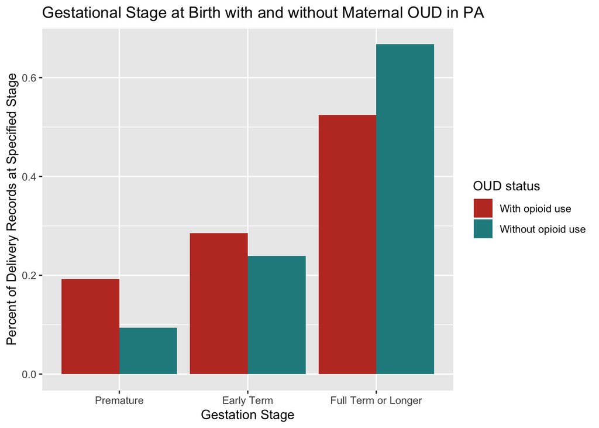

```r
PA.gestation.stage$Gestation.Stage <- factor(PA.gestation.stage$Gestation.Stage,levels = c("Premature", "Early Term", "Full Term or Longer"))

ggplot(data = PA.gestation.stage, aes(x = Gestation.Stage, y = Percent.of.Delivery.Records.at.Specified.Gestation.Stage, fill = Type.of.Category)) + geom_col(position = "dodge") +
  ggtitle("Gestational Stage at Birth with and without Maternal OUD in PA") +
  xlab("Gestation Stage") + ylab("Percent of Delivery Records at Specified Stage") +
  scale_fill_manual(values=c("#C0392B", "#238A8DFF")) +
  labs(fill = "OUD status")
```

A higher percentage of delivery records indicate newborns born premature or in early term with maternal opioid use than without. Conversely, a higher percentage of newborns are born at full term when there is not maternal opioid use. This indicates that maternal opioid use is tied to premature birth, which itself comes with a host of negative outcomes.

Graphs of readmission and medicaid usage

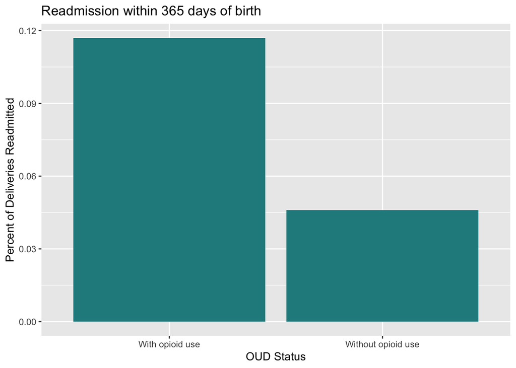

```r
ggplot(data = PA.readmission.medicaid, aes(x = Type.of.Category, y = Percent.of.Delivery.Records.that.were.Readmitted.within.365.Days)) + geom_bar(stat="identity", fill = "#238A8DFF") +
  ggtitle("Readmission within 365 days of birth") +
  xlab("OUD Status") + ylab("Percent of Deliveries Readmitted")
```

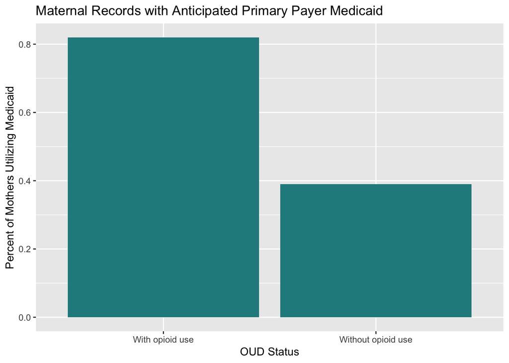

```r
ggplot(data = PA.readmission.medicaid, aes(x = Type.of.Category, y = Percent.of.Maternal.Records.with.Anticipated.Primary.Payer.Medicaid)) + geom_bar(stat="identity", fill = "#238A8DFF") +
  ggtitle("Maternal Records with Anticipated Primary Payer Medicaid") +
  xlab("OUD Status") + ylab("Percent of Mothers Utilizing Medicaid")
```

Boxplot of NAS in 2016 and 2017

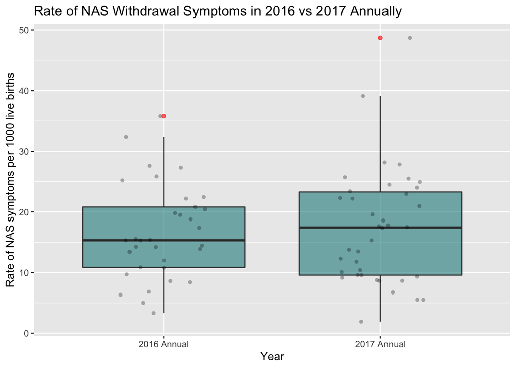

```r
county.withdrawal.stays.annual <- county.withdrawal.stays %>%
  filter(Time.Period == c("2016 Annual", "2017 Annual"))

ggplot(county.withdrawal.stays.annual, aes(x=Time.Period, y=Rate.of.Neonatal.Hospital.Stays.with.Withdrawal.Symptoms)) +
  geom_boxplot(outlier.colour="red", fill='#238A8DFF', alpha = .6) +  geom_jitter(shape=16, alpha = .3,    position=position_jitter(0.2)) +
   ggtitle("Rate of NAS Withdrawal Symptoms in 2016 vs 2017 Annually") +
  xlab("Year") + ylab("Rate of NAS symptoms per 1000 live births")
```

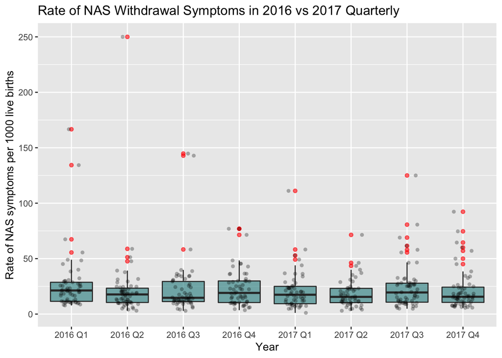

```r
county.withdrawal.stays.q <- county.withdrawal.stays %>%
  filter(Time.Period != "2016 Annual") %>%
  filter(Time.Period != "2017 Annual")


ggplot(county.withdrawal.stays.q, aes(x=Time.Period, y=Rate.of.Neonatal.Hospital.Stays.with.Withdrawal.Symptoms)) +
  geom_boxplot(outlier.colour="red", fill='#238A8DFF', alpha = .6) +  geom_jitter(shape=16, alpha = .3,    position=position_jitter(0.2)) +
   ggtitle("Rate of NAS Withdrawal Symptoms in 2016 vs 2017 Quarterly") +
  xlab("Year") + ylab("Rate of NAS symptoms per 1000 live births")
```

There is an increase in the median number of live births with NAS symptoms in 2016 vs 2017 in PA, though there is more variation within 2017.

Map of OUD and NAS

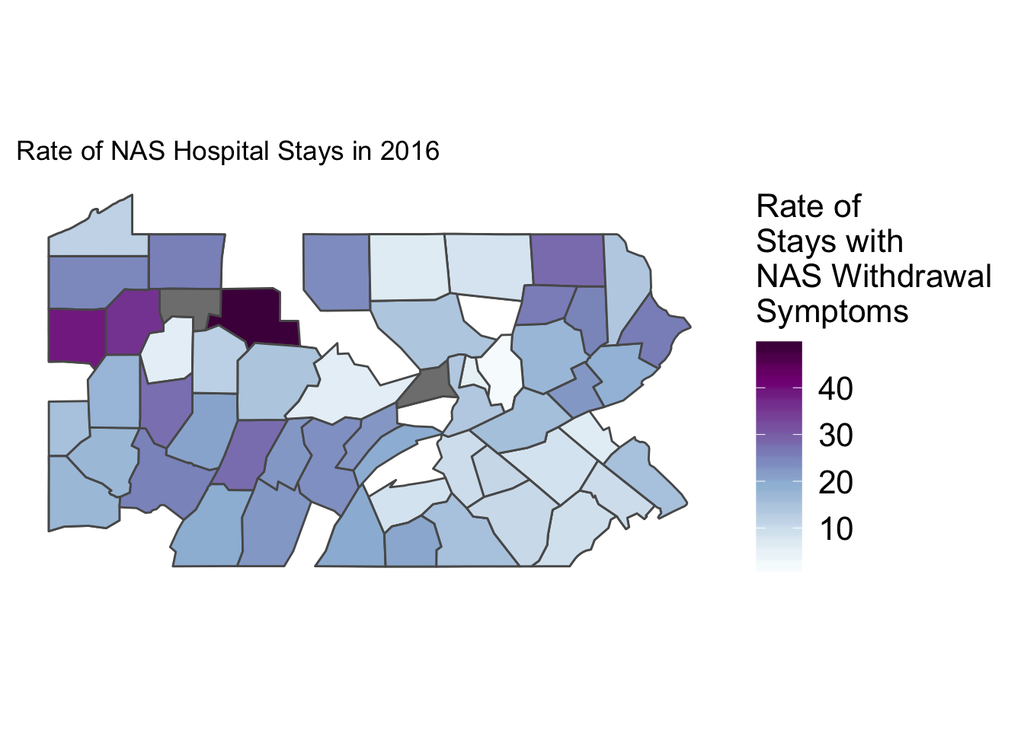

```r
counties <- readRDS(gzcon(url("https://raw.githubusercontent.com/HimesGroup/BMIN503/master/DataFiles/uscounties_2010.rds")))

counties <- counties %>%
  filter(STATE == 42) %>%
  rename(County.FIPS.Code = COUNTY)

county <-county %>%
  mutate(County.FIPS.Code = sprintf("%03d", County.FIPS.Code))

NAS.map <- inner_join(counties, county, by = "County.FIPS.Code")
NAS.map.test <- NAS.map %>%
  select(c("Rate.of.Neonatal.Hospital.Stays.with.Withdrawal.Symptoms", "geometry"))

#average rate of stays per county

myPalette <- colorRampPalette(brewer.pal(9, "BuPu"))  # RColorBrewer palette

# To save space, we can save theme commands as a function that we can "add" to calls to ggplot
my_theme <- function() {
  theme_minimal() +                                  # shorthand for white background color
  theme(axis.line = element_blank(),                 # further customization of theme components
        axis.text = element_blank(),                 # remove x and y axis text and labels
        axis.title = element_blank(),
        panel.grid = element_line(color = "white"),  # make grid lines invisible
        legend.key.size = unit(0.8, "cm"),           # increase size of legend
        legend.text = element_text(size = 16),       # increase legend text size
        legend.title = element_text(size = 16))      # increase legend title size
}

ggplot() +
  geom_sf(data = NAS.map.test, aes(fill = Rate.of.Neonatal.Hospital.Stays.with.Withdrawal.Symptoms)) +
  my_theme() +                                           # add our custom theme
  ggtitle("Rate of NAS Hospital Stays in 2016") + # add plot title
  scale_fill_gradientn(name = "Rate of \nStays with \nNAS Withdrawal \nSymptoms ",      # change legend title
                    colours = myPalette(100))            # RColorBrewer palette
```

# Conclusion

The epi data makes it clear that NAS is an increasing problem in Pennsylvania and Philadelphia, with far-reaching impacts.

The single cell data was far harder to properly analyze than I had hoped, as the original paper I planned to use for analysis used only custom CEF files and their own py algorithms for analysis; hence, the data did not translate into R well. I was able to explore a dataset from the paper “Modeling Parkinson’s disease in midbrain-like organoids” published this year, which also modeled the midbrain in an organoid model. Further work needs to be done to analyze the original and new paper to later utilize for comparison of my NAS organoid model data.

# References

La Manno G. et al. (2016) “Molecular Diversity of Midbrain Development in Mouse, Human, and Stem Cells,” Cell. 167: 566 – 580.

Maguire D. et al. (2016) “Long-Term Outcomes of Infants with Neonatal Abstinence Syndrome,” Neonatal Network. 35: 277 – 286.

McQueen K. et al. (2016) “Neonatal Abstinence Syndrome,” The New England Journal of Medicine. 375: 2469.

Patrick S. et al. (2015) “Increasing incidence and geographical distribution of neonatal abstinence syndrome: United States 2009 to 2012,” Nature America 35: 652.

Saha T. et al. (2016) “Nonmedical Prescription Opioid Use and DSM-5 Nonmedical Prescription Opioid Use Disorder in the United States,” Journal of Clinical Psychology. 77: 772–780

Smits L. et al. (2019) “Modeling Parkinson’s disease in midbrain-like organoids,” Nature Partner Journal Parkinson’s Disease" 5.